# Project - Ensemble Techniques - Travel Package Purchase Prediction

## Background and Context

A tourism company named "Visit with us" wants to enable and establish a viable business model to expand the customer base by harnessing the available data of existing and potential customers to make the marketing expenditure more efficient.

One of the ways to expand the customer base is to introduce a new offering of packages. Currently, there are 5 types of packages the company is offering - Basic, Standard, Deluxe, Super Deluxe, King. Looking at the data of the last year, it has been observed that 18% of the customers purchased the packages.

However, the marketing cost was quite high because customers were contacted at random without looking at the available information.

The company is now planning to launch a new product i.e. Wellness Tourism Package. Wellness Tourism is defined as Travel that allows the traveler to maintain, enhance or kick-start a healthy lifestyle, and support or increase one's sense of well-being.

We are required to analyze the customers' data and information to provide recommendations to the Policy Maker and Marketing Team and also build a model to predict the potential customer who is going to purchase the newly introduced travel package.

## Objective

To predict which customer is more likely to purchase the newly introduced travel package based on the available data so that customer base can be expanded and the marketing expenditure can be optimized.

## Key Questions

1. What are the key factors influencing whether a customer will buy Wellness Tourism Package or not?
2. Is there a good predictive model so that we can increase the conversion rate of targetted marketting?
3. What does the performance assessment look like for such a model?

## Data Dictionary

### Customer details:

- CustomerID: Unique customer ID
- ProdTaken: Whether the customer has purchased a package or not (0: No, 1: Yes)
- Age: Age of customer
- TypeofContact: How customer was contacted (Company Invited or Self Inquiry)
- CityTier: City tier depends on the development of a city, population, facilities, and living standards. The categories are ordered i.e. Tier 1 > Tier 2 > Tier 3
- Occupation: Occupation of customer
- Gender: Gender of customer
- NumberOfPersonVisiting: Total number of persons planning to take the trip with the customer
- PreferredPropertyStar: Preferred hotel property rating by customer
- MaritalStatus: Marital status of customer
- NumberOfTrips: Average number of trips in a year by customer
- Passport: The customer has a passport or not (0: No, 1: Yes)
- OwnCar: Whether the customers own a car or not (0: No, 1: Yes)
- NumberOfChildrenVisiting: Total number of children with age less than 5 planning to take the trip with the customer
- Designation: Designation of the customer in the current organization
- MonthlyIncome: Gross monthly income of the customer

### Customer interaction data:

- PitchSatisfactionScore: Sales pitch satisfaction score
- ProductPitched: Product pitched by the salesperson
- NumberOfFollowups: Total number of follow-ups has been done by the salesperson after the sales pitch
- DurationOfPitch: Duration of the pitch by a salesperson to the customer

## Import necessary libraries and load data

```python
# Library to suppress warnings or deprecation notes
import warnings
warnings.filterwarnings('ignore')

# Libraries to help with reading and manipulating data
import pandas as pd
import numpy as np

# Libraries to help with data visualization
import matplotlib.pyplot as plt
import seaborn as sns
%matplotlib inline

# Removes the limit from the number of displayed columns and rows.
# This is so that we can see the entire dataframe when we print it
pd.set_option('display.max_columns', None)
# pd.set_option('display.max_rows', None)
pd.set_option('display.max_rows', 200)
# We are setting the random seed via np.random.seed so that
# we get the same random results every time
np.random.seed(1)
```

```python
# Load the Tourism data from sheet Tourism of Tourism.xlsx
data = pd.read_excel('Tourism.xlsx', sheet_name='Tourism')
```

```python
print(f'Number of rows: {data.shape[0]} and number of columns: {data.shape[1]}')
```

```
Number of rows: 4888 and number of columns: 20
```

```python
# Check the first 5 rows of data
data.head()
```

|  | CustomerID | ProdTaken | Age | TypeofContact | CityTier | DurationOfPitch | Occupation | Gender | NumberOfPersonVisiting | NumberOfFollowups | ProductPitched | PreferredPropertyStar | MaritalStatus | NumberOfTrips | Passport | PitchSatisfactionScore | OwnCar | NumberOfChildrenVisiting | Designation | MonthlyIncome |
| --- | --- | --- | --- | --- | --- | --- | --- | --- | --- | --- | --- | --- | --- | --- | --- | --- | --- | --- | --- | --- |
| 0 | 200000 | 1 | 41.0 | Self Enquiry | 3 | 6.0 | Salaried | Female | 3 | 3.0 | Deluxe | 3.0 | Single | 1.0 | 1 | 2 | 1 | 0.0 | Manager | 20993.0 |
| 1 | 200001 | 0 | 49.0 | Company Invited | 1 | 14.0 | Salaried | Male | 3 | 4.0 | Deluxe | 4.0 | Divorced | 2.0 | 0 | 3 | 1 | 2.0 | Manager | 20130.0 |
| 2 | 200002 | 1 | 37.0 | Self Enquiry | 1 | 8.0 | Free Lancer | Male | 3 | 4.0 | Basic | 3.0 | Single | 7.0 | 1 | 3 | 0 | 0.0 | Executive | 17090.0 |
| 3 | 200003 | 0 | 33.0 | Company Invited | 1 | 9.0 | Salaried | Female | 2 | 3.0 | Basic | 3.0 | Divorced | 2.0 | 1 | 5 | 1 | 1.0 | Executive | 17909.0 |
| 4 | 200004 | 0 | NaN | Self Enquiry | 1 | 8.0 | Small Business | Male | 2 | 3.0 | Basic | 4.0 | Divorced | 1.0 | 0 | 5 | 1 | 0.0 | Executive | 18468.0 |

```python
# Check the last 5 rows of data
data.tail()
```

|  | CustomerID | ProdTaken | Age | TypeofContact | CityTier | DurationOfPitch | Occupation | Gender | NumberOfPersonVisiting | NumberOfFollowups | ProductPitched | PreferredPropertyStar | MaritalStatus | NumberOfTrips | Passport | PitchSatisfactionScore | OwnCar | NumberOfChildrenVisiting | Designation | MonthlyIncome |
| --- | --- | --- | --- | --- | --- | --- | --- | --- | --- | --- | --- | --- | --- | --- | --- | --- | --- | --- | --- | --- |
| 4883 | 204883 | 1 | 49.0 | Self Enquiry | 3 | 9.0 | Small Business | Male | 3 | 5.0 | Deluxe | 4.0 | Unmarried | 2.0 | 1 | 1 | 1 | 1.0 | Manager | 26576.0 |
| 4884 | 204884 | 1 | 28.0 | Company Invited | 1 | 31.0 | Salaried | Male | 4 | 5.0 | Basic | 3.0 | Single | 3.0 | 1 | 3 | 1 | 2.0 | Executive | 21212.0 |
| 4885 | 204885 | 1 | 52.0 | Self Enquiry | 3 | 17.0 | Salaried | Female | 4 | 4.0 | Standard | 4.0 | Married | 7.0 | 0 | 1 | 1 | 3.0 | Senior Manager | 31820.0 |
| 4886 | 204886 | 1 | 19.0 | Self Enquiry | 3 | 16.0 | Small Business | Male | 3 | 4.0 | Basic | 3.0 | Single | 3.0 | 0 | 5 | 0 | 2.0 | Executive | 20289.0 |
| 4887 | 204887 | 1 | 36.0 | Self Enquiry | 1 | 14.0 | Salaried | Male | 4 | 4.0 | Basic | 4.0 | Unmarried | 3.0 | 1 | 3 | 1 | 2.0 | Executive | 24041.0 |

```python
# checking column names, datatypes and number of non-null values
data.info()
```

```
<class 'pandas.core.frame.DataFrame'>
RangeIndex: 4888 entries, 0 to 4887
Data columns (total 20 columns):
 #   Column                    Non-Null Count  Dtype
---  ------                    --------------  -----
 0   CustomerID                4888 non-null   int64
 1   ProdTaken                 4888 non-null   int64
 2   Age                       4662 non-null   float64
 3   TypeofContact             4863 non-null   object
 4   CityTier                  4888 non-null   int64
 5   DurationOfPitch           4637 non-null   float64
 6   Occupation                4888 non-null   object
 7   Gender                    4888 non-null   object
 8   NumberOfPersonVisiting    4888 non-null   int64
 9   NumberOfFollowups         4843 non-null   float64
 10  ProductPitched            4888 non-null   object
 11  PreferredPropertyStar     4862 non-null   float64
 12  MaritalStatus             4888 non-null   object
 13  NumberOfTrips             4748 non-null   float64
 14  Passport                  4888 non-null   int64
 15  PitchSatisfactionScore    4888 non-null   int64
 16  OwnCar                    4888 non-null   int64
 17  NumberOfChildrenVisiting  4822 non-null   float64
 18  Designation               4888 non-null   object
 19  MonthlyIncome             4655 non-null   float64
dtypes: float64(7), int64(7), object(6)
memory usage: 763.9+ KB
```

> **Observations:**
> - CustomerID column can be dropped as it is a unique number and does not contain any useful information.
> - There are null or missing values in the data for Age, TypeofContact, DurationOfPitch, NumberOfFollowups, PreferredPropertyStar, NumberOfTrips, NumberOfChildrenVisiting and MonthlyIncome columns.
> - Both numerical and object data type columns are present in the dataset.

```python
# Take a backup of the original dataset
data_bkp = data.copy()

# Delete the CustomerID column from the working dataset
data.drop(['CustomerID'], axis=1, inplace=True)
```

```python
# Checking for duplicate rows.
data.duplicated().sum()
```

```
141
```

```python
data[data.duplicated()].sample(10)
```

|  | ProdTaken | Age | TypeofContact | CityTier | DurationOfPitch | Occupation | Gender | NumberOfPersonVisiting | NumberOfFollowups | ProductPitched | PreferredPropertyStar | MaritalStatus | NumberOfTrips | Passport | PitchSatisfactionScore | OwnCar | NumberOfChildrenVisiting | Designation | MonthlyIncome |
| --- | --- | --- | --- | --- | --- | --- | --- | --- | --- | --- | --- | --- | --- | --- | --- | --- | --- | --- | --- |
| 4068 | 0 | 33.0 | Company Invited | 3 | 15.0 | Small Business | Fe Male | 3 | 4.0 | Standard | 3.0 | Unmarried | 3.0 | 0 | 4 | 1 | 2.0 | Senior Manager | 27676.0 |
| 4569 | 0 | 34.0 | Self Enquiry | 2 | 10.0 | Salaried | Male | 3 | 4.0 | Basic | 4.0 | Married | 5.0 | 1 | 5 | 0 | 2.0 | Executive | 20955.0 |
| 1923 | 1 | 26.0 | Company Invited | 2 | 23.0 | Salaried | Female | 2 | 3.0 | Basic | 3.0 | Married | 1.0 | 1 | 5 | 0 | 1.0 | Executive | 17741.0 |
| 1551 | 0 | 35.0 | Self Enquiry | 1 | 6.0 | Small Business | Male | 1 | 4.0 | Basic | 3.0 | Single | 2.0 | 0 | 4 | 1 | 0.0 | Executive | 17859.0 |
| 4646 | 1 | 31.0 | Company Invited | 1 | 12.0 | Small Business | Female | 3 | 4.0 | Basic | 4.0 | Single | 2.0 | 0 | 3 | 0 | 1.0 | Executive | 21100.0 |
| 2131 | 0 | 43.0 | Self Enquiry | 1 | NaN | Salaried | Female | 2 | 3.0 | Deluxe | 4.0 | Married | 5.0 | 0 | 3 | 1 | 0.0 | Manager | 19765.0 |
| 1688 | 0 | 45.0 | Company Invited | 3 | 12.0 | Small Business | Fe Male | 2 | 4.0 | Standard | 3.0 | Unmarried | 7.0 | 0 | 4 | 1 | 0.0 | Senior Manager | 23865.0 |
| 2125 | 0 | 33.0 | Self Enquiry | 2 | 9.0 | Salaried | Male | 2 | 3.0 | Basic | 4.0 | Married | 4.0 | 1 | 5 | 0 | 1.0 | Executive | 17277.0 |
| 3976 | 0 | 51.0 | Self Enquiry | 1 | 14.0 | Small Business | Female | 3 | 5.0 | King | 3.0 | Married | NaN | 1 | 4 | 1 | 2.0 | VP | 37418.0 |
| 4214 | 0 | 42.0 | Self Enquiry | 3 | 9.0 | Salaried | Male | 3 | 4.0 | Super Deluxe | 4.0 | Single | 3.0 | 0 | 3 | 1 | NaN | AVP | 34693.0 |

> **Observations:**
> - There are 141 duplicated rows in the current dataset.
> - We are going to remove the duplicate rows as they will not help in model building as such.

```python
# Remove the duplicate rows and reset the index
data.drop_duplicates(ignore_index=True, inplace=True)
print(f'Number of rows: {data.shape[0]} and number of columns: {data.shape[1]}')
```

```
Number of rows: 4747 and number of columns: 19
```

```python
# Check the Summary of the data
data.describe().T
```

|  | count | mean | std | min | 25% | 50% | 75% | max |
| --- | --- | --- | --- | --- | --- | --- | --- | --- |
| ProdTaken | 4747.0 | 0.188329 | 0.391016 | 0.0 | 0.0 | 0.0 | 0.0 | 1.0 |
| Age | 4531.0 | 37.585522 | 9.328723 | 18.0 | 31.0 | 36.0 | 44.0 | 61.0 |
| CityTier | 4747.0 | 1.655151 | 0.917416 | 1.0 | 1.0 | 1.0 | 3.0 | 3.0 |
| DurationOfPitch | 4501.0 | 15.510998 | 8.535634 | 5.0 | 9.0 | 13.0 | 20.0 | 127.0 |
| NumberOfPersonVisiting | 4747.0 | 2.911734 | 0.724040 | 1.0 | 2.0 | 3.0 | 3.0 | 5.0 |
| NumberOfFollowups | 4703.0 | 3.705082 | 1.008677 | 1.0 | 3.0 | 4.0 | 4.0 | 6.0 |
| PreferredPropertyStar | 4721.0 | 3.583351 | 0.800351 | 3.0 | 3.0 | 3.0 | 4.0 | 5.0 |
| NumberOfTrips | 4609.0 | 3.233239 | 1.847851 | 1.0 | 2.0 | 3.0 | 4.0 | 22.0 |
| Passport | 4747.0 | 0.289657 | 0.453651 | 0.0 | 0.0 | 0.0 | 1.0 | 1.0 |
| PitchSatisfactionScore | 4747.0 | 3.051612 | 1.369584 | 1.0 | 2.0 | 3.0 | 4.0 | 5.0 |
| OwnCar | 4747.0 | 0.617653 | 0.486012 | 0.0 | 0.0 | 1.0 | 1.0 | 1.0 |
| NumberOfChildrenVisiting | 4687.0 | 1.193514 | 0.860461 | 0.0 | 1.0 | 1.0 | 2.0 | 3.0 |
| MonthlyIncome | 4523.0 | 23602.239443 | 5385.503223 | 1000.0 | 20337.0 | 22311.0 | 25535.5 | 98678.0 |

Let's check the summary of other categorical variables, including the null values if any.

```python
cat_cols = data.select_dtypes(include=["object", "category"]).columns
for col in cat_cols:
    print('>> Domain of: ', col)
    print('-------------------------------')
    cat = data[col].value_counts(dropna=False).sort_values(ascending=False)
    print(cat)
    print('-------------------------------\n')
```

```
>> Domain of:  TypeofContact
-------------------------------
Self Enquiry       3350
Company Invited    1372
NaN                  25
Name: TypeofContact, dtype: int64
-------------------------------

>> Domain of:  Occupation
-------------------------------
Salaried          2293
Small Business    2028
Large Business     424
Free Lancer          2
Name: Occupation, dtype: int64
-------------------------------

>> Domain of:  Gender
-------------------------------
Male       2835
Female     1769
Fe Male     143
Name: Gender, dtype: int64
-------------------------------

>> Domain of:  ProductPitched
-------------------------------
Basic           1800
Deluxe          1684
Standard         714
Super Deluxe     324
King             225
Name: ProductPitched, dtype: int64
-------------------------------

>> Domain of:  MaritalStatus
-------------------------------
Married      2279
Divorced      950
Single        875
Unmarried     643
Name: MaritalStatus, dtype: int64
-------------------------------

>> Domain of:  Designation
-------------------------------
Executive         1800
Manager           1684
Senior Manager     714
AVP                324
VP                 225
Name: Designation, dtype: int64
-------------------------------
```

> **Observations:**
> - *TypeofContact*: There are **25 missing values** otheriwise it has two unique values.
> - *Occupation*: Consists of four unique values majority are Salaried and Small Business.
> - *Gender*: **143 rows has value "Fe Male"** this needs to be treated as **"Female"**
> - *ProductPitched*: There are 5 different types of products as stated in the problem description.
> - *MaritalStatus*: Single and Unmarried will be treated differently based on the advice.
> - *Designation*: Looks good with 5 different designations majority are Executive and Manager.

## Fix missing and wrong values

We already know that there are null or missing values in many columns and also some wrong values such as "Fe Male". Let us fix these issues in the dataset.

```python
data.isnull().sum()
```

```
ProdTaken                     0
Age                         216
TypeofContact                25
CityTier                      0
DurationOfPitch             246
Occupation                    0
Gender                        0
NumberOfPersonVisiting        0
NumberOfFollowups            44
ProductPitched                0
PreferredPropertyStar        26
MaritalStatus                 0
NumberOfTrips               138
Passport                      0
PitchSatisfactionScore        0
OwnCar                        0
NumberOfChildrenVisiting     60
Designation                   0
MonthlyIncome               224
dtype: int64
```

```python
# Take a look at the sample data where Age is null to see if there are any patterns
data[data.Age.isnull()].sample(10)
```

|  | ProdTaken | Age | TypeofContact | CityTier | DurationOfPitch | Occupation | Gender | NumberOfPersonVisiting | NumberOfFollowups | ProductPitched | PreferredPropertyStar | MaritalStatus | NumberOfTrips | Passport | PitchSatisfactionScore | OwnCar | NumberOfChildrenVisiting | Designation | MonthlyIncome |
| --- | --- | --- | --- | --- | --- | --- | --- | --- | --- | --- | --- | --- | --- | --- | --- | --- | --- | --- | --- |
| 995 | 0 | NaN | Self Enquiry | 1 | 12.0 | Small Business | Female | 3 | 4.0 | Deluxe | 3.0 | Single | 2.0 | 1 | 4 | 1 | 1.0 | Manager | NaN |
| 1749 | 0 | NaN | Company Invited | 1 | 24.0 | Salaried | Male | 2 | 1.0 | Basic | 3.0 | Married | 5.0 | 0 | 5 | 1 | 1.0 | Executive | 18688.0 |
| 1168 | 0 | NaN | Company Invited | 1 | 8.0 | Large Business | Female | 2 | 3.0 | Basic | 3.0 | Single | 2.0 | 1 | 3 | 1 | 1.0 | Executive | NaN |
| 1157 | 0 | NaN | Company Invited | 1 | 14.0 | Salaried | Female | 2 | 3.0 | Deluxe | 3.0 | Married | 2.0 | 0 | 5 | 1 | 1.0 | Manager | NaN |
| 1291 | 1 | NaN | Self Enquiry | 1 | 16.0 | Small Business | Male | 2 | 3.0 | Deluxe | 5.0 | Single | 2.0 | 0 | 4 | 0 | 0.0 | Manager | NaN |
| 1032 | 1 | NaN | Company Invited | 1 | 8.0 | Salaried | Female | 2 | 4.0 | Basic | 5.0 | Single | 3.0 | 1 | 3 | 0 | 0.0 | Executive | 18646.0 |
| 865 | 0 | NaN | Self Enquiry | 3 | 35.0 | Salaried | Male | 3 | 3.0 | Deluxe | 5.0 | Married | 1.0 | 0 | 2 | 1 | 1.0 | Manager | NaN |
| 88 | 0 | NaN | Self Enquiry | 1 | 8.0 | Salaried | Male | 2 | 4.0 | Deluxe | 3.0 | Divorced | 2.0 | 0 | 4 | 1 | 0.0 | Manager | NaN |
| 1519 | 1 | NaN | Self Enquiry | 1 | 11.0 | Large Business | Male | 2 | 3.0 | Basic | 3.0 | Single | 2.0 | 1 | 1 | 0 | 0.0 | Executive | 18441.0 |
| 2357 | 1 | NaN | Self Enquiry | 3 | 22.0 | Small Business | Male | 3 | 3.0 | Standard | 3.0 | Married | 3.0 | 0 | 5 | 0 | 1.0 | Senior Manager | 18544.0 |

### Fix Gender column values

```python
#Correcting the Gender
data['Gender'] = data['Gender'].apply(lambda x: x if x != 'Fe Male' else 'Female')
```

```python
data['Gender'].value_counts()
```

```
Male      2835
Female    1912
Name: Gender, dtype: int64
```

### Fix TypeofContact column values

Null values of TypeofContact will be filled with the mode value since there are only 25 of them.

```python
# Handling Type of contact
data['TypeofContact'] = data['TypeofContact'].fillna('Self Enquiry')
```

```python
data['TypeofContact'].value_counts()
```

```
Self Enquiry       3375
Company Invited    1372
Name: TypeofContact, dtype: int64
```

### Fix Age and MonthlyIncome column values

Missing values of Age and MonthlyIncome will be replaced with median.

```python
#Fill Age null values with Median Age
for col in ['Age', 'MonthlyIncome']:
    data[col] = data[col].fillna(data[col].median())
```

### Fix Others column values

All othere missing values will be filled up with mean.

```python
cols =['NumberOfFollowups', 'DurationOfPitch', 'PreferredPropertyStar', 'NumberOfTrips', 'NumberOfChildrenVisiting']
for col in cols:
    data[col] =  data[col].fillna(round(data[col].mean()))
```

Finally let's again check if there are any missing values pending to be treated.

```python
data.isnull().sum()
```

```
ProdTaken                   0
Age                         0
TypeofContact               0
CityTier                    0
DurationOfPitch             0
Occupation                  0
Gender                      0
NumberOfPersonVisiting      0
NumberOfFollowups           0
ProductPitched              0
PreferredPropertyStar       0
MaritalStatus               0
NumberOfTrips               0
Passport                    0
PitchSatisfactionScore      0
OwnCar                      0
NumberOfChildrenVisiting    0
Designation                 0
MonthlyIncome               0
dtype: int64
```

```python
# Dataset has no more missing values, lets take a look at the first 5 rows.
data.head()
```

|  | ProdTaken | Age | TypeofContact | CityTier | DurationOfPitch | Occupation | Gender | NumberOfPersonVisiting | NumberOfFollowups | ProductPitched | PreferredPropertyStar | MaritalStatus | NumberOfTrips | Passport | PitchSatisfactionScore | OwnCar | NumberOfChildrenVisiting | Designation | MonthlyIncome |
| --- | --- | --- | --- | --- | --- | --- | --- | --- | --- | --- | --- | --- | --- | --- | --- | --- | --- | --- | --- |
| 0 | 1 | 41.0 | Self Enquiry | 3 | 6.0 | Salaried | Female | 3 | 3.0 | Deluxe | 3.0 | Single | 1.0 | 1 | 2 | 1 | 0.0 | Manager | 20993.0 |
| 1 | 0 | 49.0 | Company Invited | 1 | 14.0 | Salaried | Male | 3 | 4.0 | Deluxe | 4.0 | Divorced | 2.0 | 0 | 3 | 1 | 2.0 | Manager | 20130.0 |
| 2 | 1 | 37.0 | Self Enquiry | 1 | 8.0 | Free Lancer | Male | 3 | 4.0 | Basic | 3.0 | Single | 7.0 | 1 | 3 | 0 | 0.0 | Executive | 17090.0 |
| 3 | 0 | 33.0 | Company Invited | 1 | 9.0 | Salaried | Female | 2 | 3.0 | Basic | 3.0 | Divorced | 2.0 | 1 | 5 | 1 | 1.0 | Executive | 17909.0 |
| 4 | 0 | 36.0 | Self Enquiry | 1 | 8.0 | Small Business | Male | 2 | 3.0 | Basic | 4.0 | Divorced | 1.0 | 0 | 5 | 1 | 0.0 | Executive | 18468.0 |

## Univariate Analysis

For making the univariate analysis easier, we define below functions that will help us to plot both non-categorical columns such as Age, MonthlyIncome etc. as box and hist plots and categorical columns such as TypeofContact, CityTier, Occupation etc. as count plot with percentages.

```python
# function to plot a boxplot and a histogram along the same scale.
def box_hist_plot(data, feature, figsize=(12, 7), bins=20):
    """
    This will show a box and hist plot in a column alignment, For hist plot kde is set to True

    data: dataframe
    feature: dataframe column
    figsize: size of figure (default (12,7))
    """
    # creating the 2 subplots
    f2, (ax_box2, ax_hist2) = plt.subplots(
        nrows=2,  # Number of rows of the subplot grid= 2
        sharex=True,  # x-axis will be shared among all subplots
        gridspec_kw={"height_ratios": (0.25, 0.75)},
        figsize=figsize,
    )
    # boxplot will be created and a star will indicate the mean value of the column
    sns.boxplot(data=data, x=feature, ax=ax_box2, showmeans=True, color="violet")
    # For hist plot
    sns.histplot(data=data, x=feature, kde=True, bins=bins, ax=ax_hist2)
    # Add mean to the histogram
    ax_hist2.axvline(data[feature].mean(), color="green", linestyle="--")
    # Add median to the histogram
    ax_hist2.axvline(data[feature].median(), color="black", linestyle="-")
```

```python
# function to create bar plot with percent labels
def bar_perc_plot(data, feature):
    """
    Barplot with percentage at the top

    data: dataframe
    feature: dataframe column
    """

    # calculate the fig width dynamically
    total = len(data[feature])
    count = data[feature].nunique()
    plt.figure(figsize=(count + 1, 5))

    plt.xticks(rotation=90, fontsize=15)
    ax = sns.countplot(
        data=data,
        x=feature,
        palette="Paired",
        # Sort the bars from high to low
        order=data[feature].value_counts().sort_values(ascending=False).index,
    )

    for bar in ax.patches:
        # percentage of each class of the category
        label = "{:.2f}%".format(100 * bar.get_height() / total)
        x = bar.get_x() + bar.get_width() / 2  # width of the plot
        y = bar.get_height()  # height of the plot

        # annotate the percentage
        ax.annotate(
            label,
            (x, y),
            ha="center",
            va="center",
            size=12,
            xytext=(0, 5),
            textcoords="offset points",
        )

    plt.show();  # show the plot
```

### Analysis of Age

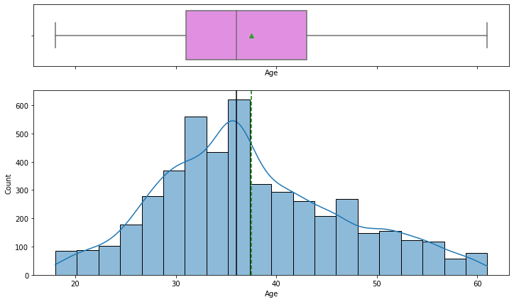

```python
#Age
box_hist_plot(data, 'Age')
```

> **Observations:**
> - Majority of customers are between 30 to 40 years.
> - Mean and median of the customers are between 35 to 40 years.
> - Age is normally distributed and there are no outliers

### Analysis of DurationOfPitch

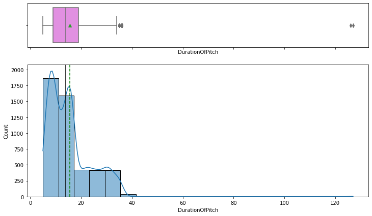

```python
#DurationOfPitch
box_hist_plot(data, 'DurationOfPitch')
```

> **Observations:**
> - Duration of pitch has a right skew because of few outliers.
> - Mean and median of pitch is around 15 mins.

```python
# Check the durations above 45 mins
data[data.DurationOfPitch > 45]
```

|  | ProdTaken | Age | TypeofContact | CityTier | DurationOfPitch | Occupation | Gender | NumberOfPersonVisiting | NumberOfFollowups | ProductPitched | PreferredPropertyStar | MaritalStatus | NumberOfTrips | Passport | PitchSatisfactionScore | OwnCar | NumberOfChildrenVisiting | Designation | MonthlyIncome |
| --- | --- | --- | --- | --- | --- | --- | --- | --- | --- | --- | --- | --- | --- | --- | --- | --- | --- | --- | --- |
| 1434 | 0 | 36.0 | Company Invited | 3 | 126.0 | Salaried | Male | 2 | 3.0 | Basic | 3.0 | Married | 3.0 | 0 | 1 | 1 | 1.0 | Executive | 18482.0 |
| 3808 | 0 | 53.0 | Company Invited | 3 | 127.0 | Salaried | Male | 3 | 4.0 | Basic | 3.0 | Married | 4.0 | 0 | 1 | 1 | 2.0 | Executive | 22160.0 |

```python
# it seems there are only two rows with such high values and both of these customers have ot taken the product.
# Lets set their value to max 45 mins
data['DurationOfPitch'] = data['DurationOfPitch'].apply(lambda x: x if x < 45 else 45)
```

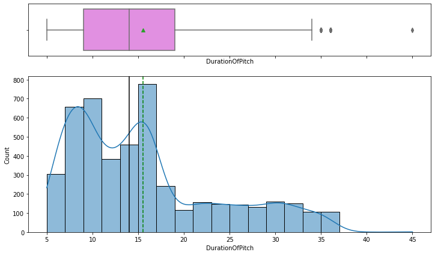

```python
box_hist_plot(data, 'DurationOfPitch')
```

Now the Duration of pitch seems normally distributed although it is right skewed.

### Analysis of MonthlyIncome

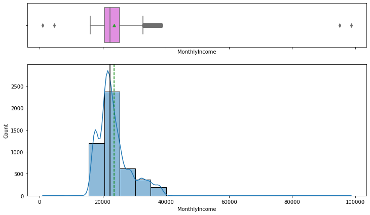

```python
box_hist_plot(data, 'MonthlyIncome')
```

> **Observations:**
> - Monthly income is also right skewed distribution.
> - Median monthly income is around 22K. We are not sure about the currency but outliers which are closed to 100K seems very high.

We can guess the monthly income from the median value of income based on designations. But first lets check the outliers which are more than 50K.

```python
data[data.MonthlyIncome > 50000]
```

|  | ProdTaken | Age | TypeofContact | CityTier | DurationOfPitch | Occupation | Gender | NumberOfPersonVisiting | NumberOfFollowups | ProductPitched | PreferredPropertyStar | MaritalStatus | NumberOfTrips | Passport | PitchSatisfactionScore | OwnCar | NumberOfChildrenVisiting | Designation | MonthlyIncome |
| --- | --- | --- | --- | --- | --- | --- | --- | --- | --- | --- | --- | --- | --- | --- | --- | --- | --- | --- | --- |
| 38 | 0 | 36.0 | Self Enquiry | 1 | 11.0 | Salaried | Female | 2 | 4.0 | Basic | 4.0 | Divorced | 1.0 | 1 | 2 | 1 | 0.0 | Executive | 95000.0 |
| 2412 | 0 | 37.0 | Self Enquiry | 1 | 12.0 | Salaried | Female | 3 | 5.0 | Basic | 5.0 | Divorced | 2.0 | 1 | 2 | 1 | 1.0 | Executive | 98678.0 |

```python
# Check monthly income median based grouped by designation.
data.groupby('Designation')['MonthlyIncome'].apply(lambda x: x.median())
```

```
Designation
AVP               32181.0
Executive         20755.5
Manager           22689.0
Senior Manager    26505.5
VP                34999.0
Name: MonthlyIncome, dtype: float64
```

Since the outliers are Executive with median income around 20K, it is very unlikely that they will have monthly income around 100K. Lets set these income values to Executive median income.

```python
data['MonthlyIncome'] = data['MonthlyIncome'].apply(lambda x: x if x < 50000 else 20755)
```

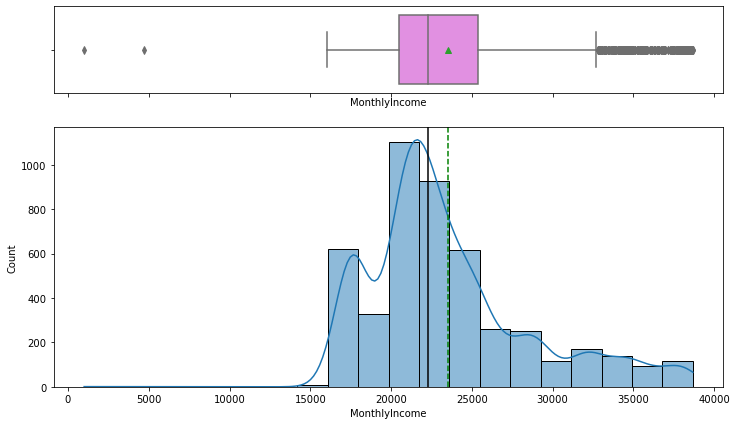

```python
box_hist_plot(data, 'MonthlyIncome')
```

Now the Monthly income is centrally distributed although there are outliers but they are acceptable based on the designations.

### Analysis of ProdTaken

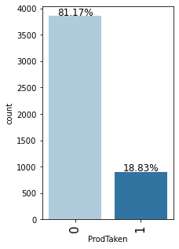

```python
bar_perc_plot(data, 'ProdTaken')
```

> **Observations:**
> - Only 18.8% customers have bought travel packages in the given dataset.
> - Most of the customers have not bought any travel package, which means we have an unbalanced dataset.

### Analysis of TypeofContact

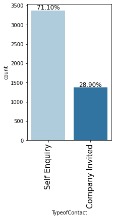

```python
bar_perc_plot(data, 'TypeofContact')
```

> **Observations:**
> - Company invited customers are around 29%.
> - Self enquiry customers are around 71%. We would have expected that self enquiry customers should by the travel packages but it appears that is not the case, there are factors which are discouraging a self enquired customer to move away and only 18.8% of all customers have bought travel package.

### Analysis of CityTier

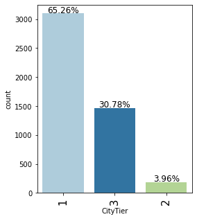

```python
bar_perc_plot(data, 'CityTier')
```

### Analysis of Occupation

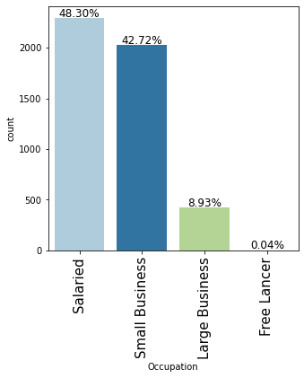

```python
bar_perc_plot(data, 'Occupation')
```

> **Observations:**
> - Most of the customers are Salaried and Small Business.
> - We have around 9% Large Business customers and negligible number of Free Lancers.

### Analysis of Gender

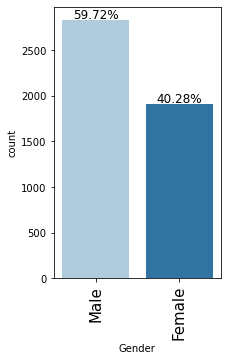

```python
bar_perc_plot(data, 'Gender')
```

> **Observations:**
> - Around 60% of our customers are Male.
> - A little over 40% customers are Female.

### Analysis of NumberOfPersonVisiting

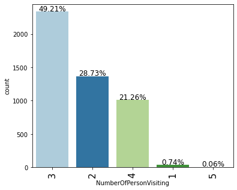

```python
bar_perc_plot(data, 'NumberOfPersonVisiting')
```

> **Observations:**
> - Most NumberOfPersonVisiting is 3 followed by 2 and 4 members.
> - NumberOfPersonVisiting alone or higher than 4 are very small.

### Analysis of NumberOfFollowups

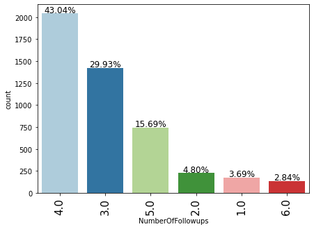

```python
bar_perc_plot(data, 'NumberOfFollowups')
```

> **Observations:**
> - Most of the customers were followed up 4 times followed by 3 and 5 times.
> - Number of customers who were followed by for very less time such as 1 or 2 or more than 5 are less.

### Analysis of ProductPitched

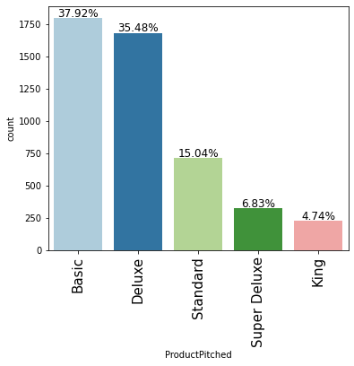

```python
bar_perc_plot(data, 'ProductPitched')
```

Although the dataset has the above five travel products but for this analysis we are interested in another product namely Wellness Travel Package. During model building we will encode his column as ordered numerical values as we are not interested in these existing products.

### Analysis of PreferredPropertyStar

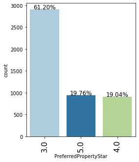

```python
bar_perc_plot(data, 'PreferredPropertyStar')
```

> **Observations:**
> - Around 61% customers preferred 3 star rated properties.
> - 5 and 4 star rated properties are prefferred by almost equal number of customers - around 20% each.

### Analysis of MaritalStatus

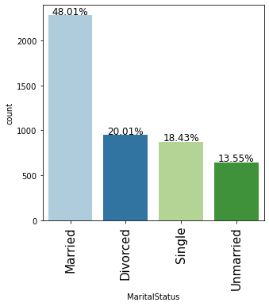

```python
bar_perc_plot(data, 'MaritalStatus')
```

> **Observations:**
> - Most customers around 48% in the dataset are Married.
> - Around 20% customers are Divorced followed by Single and Unmarried.

### Analysis of NumberOfTrips

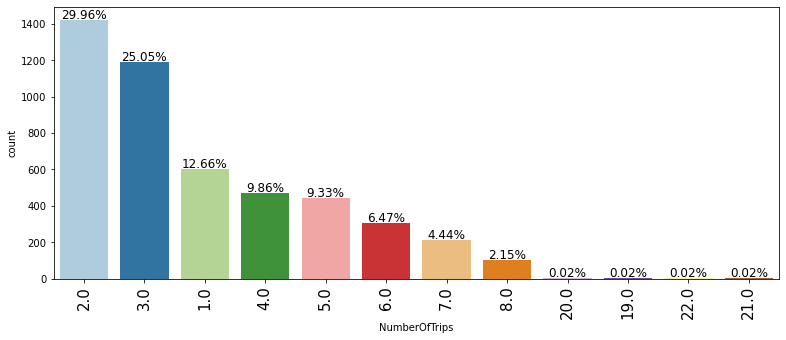

```python
bar_perc_plot(data, 'NumberOfTrips')
```

> **Observations:**
> - Around 30% of customers have 2 trips per year followed by 3 and one trip per year.
> - There are few customers having 19 or more trips per year which is very unusual.

Let's check how many customers have number of trips more than 8.

```python
data[data.NumberOfTrips > 8]
```

|  | ProdTaken | Age | TypeofContact | CityTier | DurationOfPitch | Occupation | Gender | NumberOfPersonVisiting | NumberOfFollowups | ProductPitched | PreferredPropertyStar | MaritalStatus | NumberOfTrips | Passport | PitchSatisfactionScore | OwnCar | NumberOfChildrenVisiting | Designation | MonthlyIncome |
| --- | --- | --- | --- | --- | --- | --- | --- | --- | --- | --- | --- | --- | --- | --- | --- | --- | --- | --- | --- |
| 385 | 1 | 30.0 | Company Invited | 1 | 10.0 | Large Business | Male | 2 | 3.0 | Basic | 3.0 | Single | 19.0 | 1 | 4 | 1 | 1.0 | Executive | 17285.0 |
| 816 | 0 | 39.0 | Company Invited | 1 | 15.0 | Salaried | Male | 3 | 3.0 | Deluxe | 4.0 | Unmarried | 21.0 | 0 | 2 | 1 | 0.0 | Manager | 21782.0 |
| 2759 | 1 | 31.0 | Company Invited | 1 | 11.0 | Large Business | Male | 3 | 4.0 | Basic | 3.0 | Single | 20.0 | 1 | 4 | 1 | 2.0 | Executive | 20963.0 |
| 3190 | 0 | 40.0 | Company Invited | 1 | 16.0 | Salaried | Male | 4 | 4.0 | Deluxe | 4.0 | Unmarried | 22.0 | 0 | 2 | 1 | 1.0 | Manager | 25460.0 |

```python
# There are only 4 customers having Number of trips more than 8.
# In order to fix these outliers, for these customers we are going to set the number of trips to 8.
data['NumberOfTrips'] = data['NumberOfTrips'].apply(lambda x: x if x < 8 else 8)
```

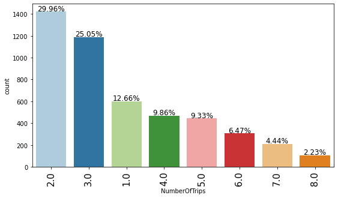

```python
# See the distribution of NumberOfTrips after outlier treatment
bar_perc_plot(data, 'NumberOfTrips')
```

### Analysis of PitchSatisfactionScore

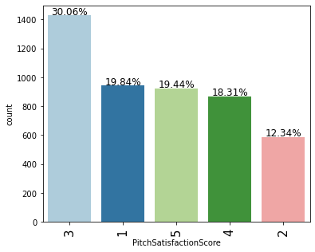

```python
bar_perc_plot(data, 'PitchSatisfactionScore')
```

> **Observations:**
> - Majority of customers (30%) have given satisfaction score as 3.
> - However around more than 30% customer has given low satisfaction scores like 1 or 2. Company should investigate this issue.
> - Around 40% of customers have given very good satisfaction score either 4 or 5.

### Analysis of OwnCar

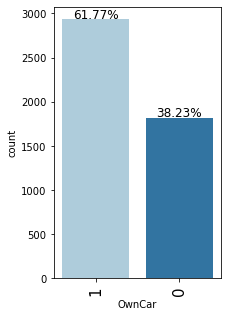

```python
bar_perc_plot(data, 'OwnCar')
```

> **Observations:**
> - A little over 60% customers in the dataset own a car.
> - However close to 40% customers don't own a car.

### Analysis of NumberOfChildrenVisiting

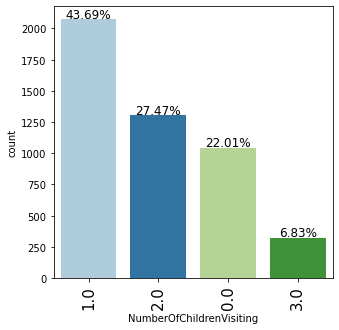

```python
bar_perc_plot(data, 'NumberOfChildrenVisiting')
```

> **Observations:**
> - Majority of customers planed to travel had one child followed by 2.
> - 22% customers reported no accompanying children.
> - 3 or more children accompanied in the trip are very less around 7%.

### Analysis of Designation

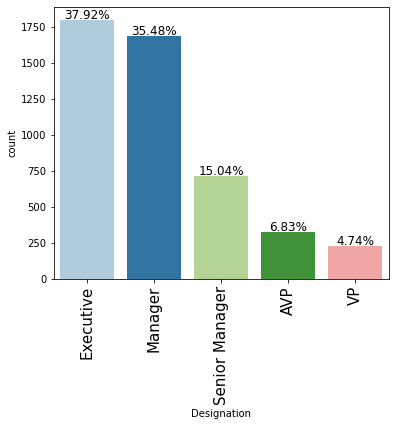

```python
bar_perc_plot(data, 'Designation')
```

> **Observations:**
> - There are five different designations, majority of the customers are Executive or Manager.
> - Higher designation customers such as AVP and VP are less in number.

Company designation does not generally decide a person's travel package buying. It is more corelated with Age and monthly income. Hence we are encode this data as ordered numerical feature before running our model.

## Multi-Variate Analysis

### Distribution of Product Taken with Non-Categorical features

Ignoring the outliers let's check the distribution of Product Taken based on the non-categorical features

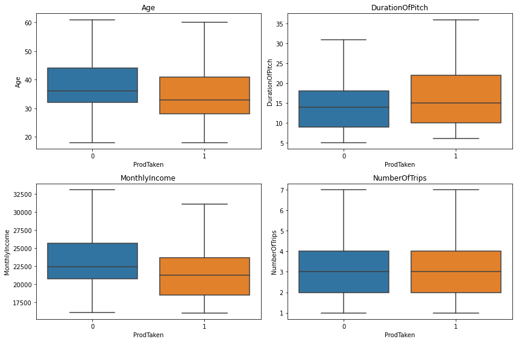

```python
cols = data[
    [
        "Age",
        "DurationOfPitch",
        "MonthlyIncome",
        "NumberOfTrips"
    ]
].columns.tolist()
plt.figure(figsize=(12, 8))

for i, variable in enumerate(cols):
    plt.subplot(2, 2, i + 1)
    sns.boxplot(data = data, x="ProdTaken", y=variable, showfliers=False)
    plt.tight_layout()
    plt.title(variable)
plt.show()
```

> **Observations:**
> - Mostly younger age people from 25 years to 40 years has taken a travel package.
> - Also the customers who have taken a travel package, duration of pitch is higher.
> - Relatively lower monthly income group people such as Executives and Managers have taken a travel package.
> - Distribution of customers by ProdTaken and NumberOfTrips have no difference.

Now let's check the distribution of product taken customers with regards to categorical values.

```python
# function to count and a normalized stack bar chart
def count_and_normalize_plot(data, predictor, target):
    """
    Print the category counts and plot a normalized stacked bar chart

    data: dataframe
    predictor: independent variable
    target: target variable
    """
    count = data[predictor].nunique()
    sorter = data[target].value_counts().index[-1]
    tab1 = pd.crosstab(data[predictor], data[target], margins=True).sort_values(
        by=sorter, ascending=False
    )
    print(tab1)
    print("-" * 100)

    fig = plt.figure(figsize=(14,5))

    # Add the first plot
    ax1 = fig.add_subplot(121)
    ax1.set_title(predictor + ' by ' + target)
    sns.countplot(data = data, x=target, hue=predictor, ax=ax1)

    # Add the second plot
    ax2 = fig.add_subplot(122)
    ax2.set_title('Normalized ' + predictor + ' by ' + target)
    tab = pd.crosstab(data[predictor], data[target], normalize="index").sort_values(
        by=sorter, ascending=False
    )
    tab.plot(kind="bar", stacked=True, ax=ax2)
    plt.legend(
        loc="lower left",
        frameon=False,
    )
    plt.legend(loc="upper left", bbox_to_anchor=(1, 1))
    plt.show()
```

#### TypeofContact Vs ProdTaken

```
ProdTaken           0    1   All
TypeofContact
All              3853  894  4747
Self Enquiry     2775  600  3375
Company Invited  1078  294  1372
----------------------------------------------------------------------------------------------------
```

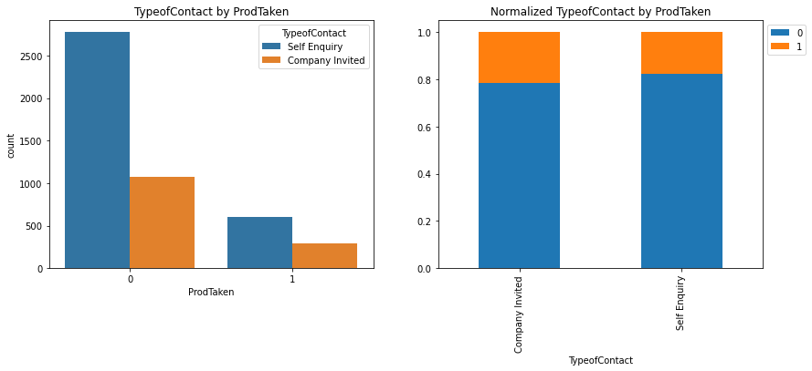

```python
count_and_normalize_plot(data, 'TypeofContact', 'ProdTaken')
```

> **Observations:**
> - Self enquiry customers are more in the product taken category which is makes sense.
> - However from the normalized chart we see that **higher percentage of company invited customers** have taken a travel package.

#### CityTier Vs ProdTaken

```
ProdTaken     0    1   All
CityTier
All        3853  894  4747
1          2592  506  3098
3          1115  346  1461
2           146   42   188
----------------------------------------------------------------------------------------------------
```

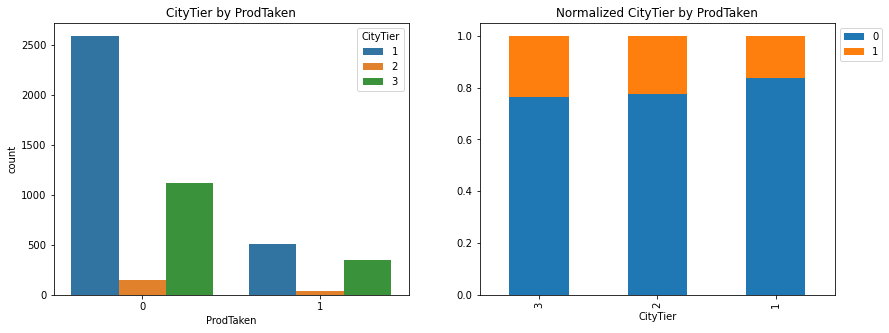

```python
count_and_normalize_plot(data, 'CityTier', 'ProdTaken')
```

> **Observations:**
> - Customers who have taken travel package are mainly from Tier 1 and 3 cities.
> - However, normalized chart shows that **higher percentage of Tier 3 city customers** have taken a travel package.

#### Occupation Vs ProdTaken

```
ProdTaken          0    1   All
Occupation
All             3853  894  4747
Salaried        1893  400  2293
Small Business  1654  374  2028
Large Business   306  118   424
Free Lancer        0    2     2
----------------------------------------------------------------------------------------------------
```

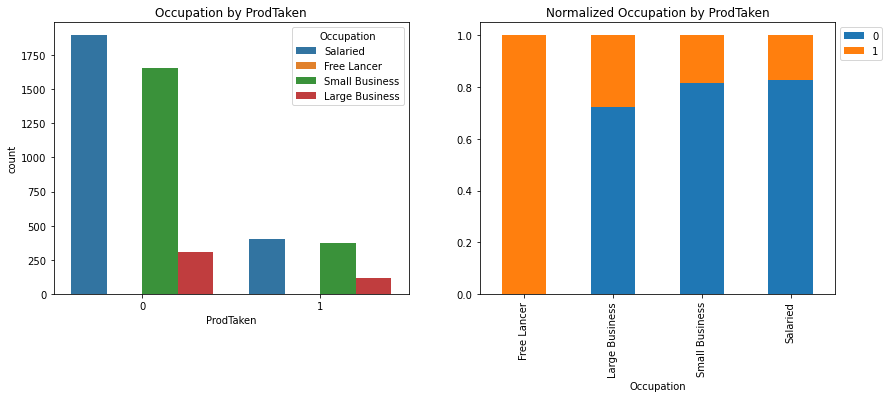

```python
count_and_normalize_plot(data, 'Occupation', 'ProdTaken')
```

> **Observations:**
> - Salaried and Small business customers are more in the product taken category.
> - However **higher percentage of Large Business customers** have taken a travel package.
> - Since data points for Free Lancer customers are only 2 we cannot make any conclusion.

#### Gender Vs ProdTaken

```
ProdTaken     0    1   All
Gender
All        3853  894  4747
Male       2273  562  2835
Female     1580  332  1912
----------------------------------------------------------------------------------------------------
```

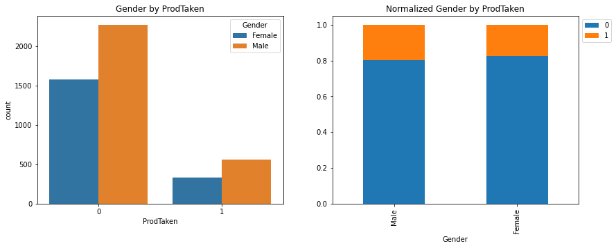

```python
count_and_normalize_plot(data, 'Gender', 'ProdTaken')
```

> **Observations:**
> - More Male customers have taken travel packages.
> - Also slightly higher percentage of Male customers have taken a product compared to Female customers.

#### NumberOfPersonVisiting Vs ProdTaken

```
ProdTaken                  0    1   All
NumberOfPersonVisiting
All                     3853  894  4747
3                       1889  447  2336
2                       1108  256  1364
4                        818  191  1009
1                         35    0    35
5                          3    0     3
----------------------------------------------------------------------------------------------------
```

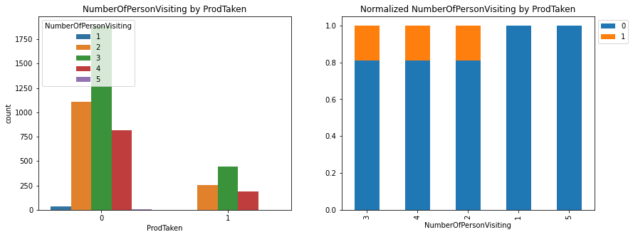

```python
count_and_normalize_plot(data, 'NumberOfPersonVisiting', 'ProdTaken')
```

> **Observations:**
> - Customers who planned to visit with 2 to 4 persons have taken a product.
> - Most of the customers who have taken a travel product planned to visit with 3 persons.
> - There are no data points for customers who have taken a product and planned to visit wither with 1 or 5 persons.

#### NumberOfFollowups Vs ProdTaken

```
ProdTaken             0    1   All
NumberOfFollowups
All                3853  894  4747
4.0                1668  375  2043
3.0                1187  234  1421
5.0                 557  188   745
6.0                  82   53   135
2.0                 204   24   228
1.0                 155   20   175
----------------------------------------------------------------------------------------------------
```

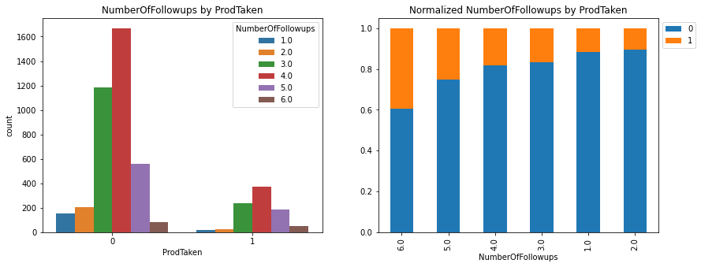

```python
count_and_normalize_plot(data, 'NumberOfFollowups', 'ProdTaken')
```

> **Observations:**
> - Most number of customers who took a travel package was followed up 4 times.
> - However from the normalized chart we see that **higher percentage of customers taken a product who were followed up more** like 5 or 6 times.

#### ProductPitched Vs ProdTaken

```
ProdTaken          0    1   All
ProductPitched
All             3853  894  4747
Basic           1260  540  1800
Deluxe          1486  198  1684
Standard         594  120   714
King             205   20   225
Super Deluxe     308   16   324
----------------------------------------------------------------------------------------------------
```

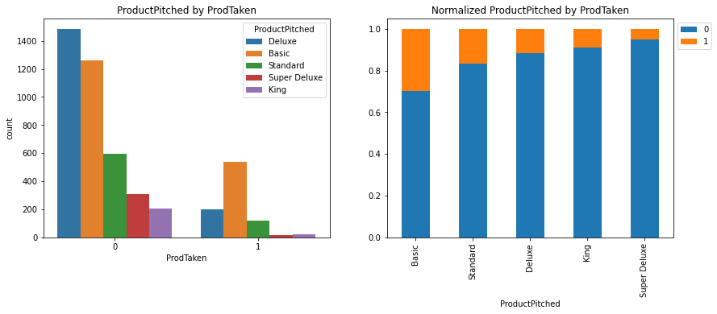

```python
count_and_normalize_plot(data, 'ProductPitched', 'ProdTaken')
```

#### PreferredPropertyStar Vs ProdTaken

```
ProdTaken                 0    1   All
PreferredPropertyStar
All                    3853  894  4747
3.0                    2435  470  2905
5.0                     696  242   938
4.0                     722  182   904
----------------------------------------------------------------------------------------------------
```

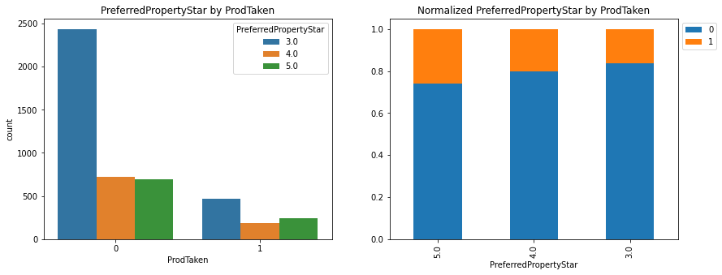

```python
count_and_normalize_plot(data, 'PreferredPropertyStar', 'ProdTaken')
```

> **Observations:**
> - Most of the customers who took a product preferred 3 start rating properties.
> - However **higher percentage of customers who preferred 5 and 4 property ratings** have taken a travel package.

#### MaritalStatus Vs ProdTaken

```
ProdTaken         0    1   All
MaritalStatus
All            3853  894  4747
Married        1965  314  2279
Single          578  297   875
Unmarried       484  159   643
Divorced        826  124   950
----------------------------------------------------------------------------------------------------
```

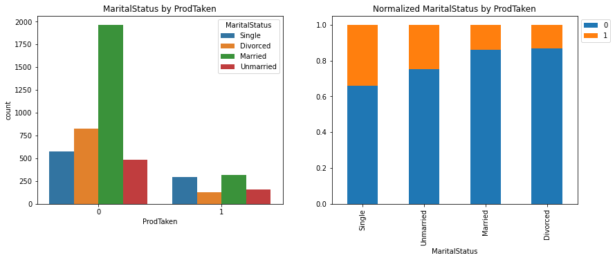

```python
count_and_normalize_plot(data, 'MaritalStatus', 'ProdTaken')
```

#### Passport Vs ProdTaken

```
ProdTaken     0    1   All
Passport
All        3853  894  4747
1           895  480  1375
0          2958  414  3372
----------------------------------------------------------------------------------------------------
```

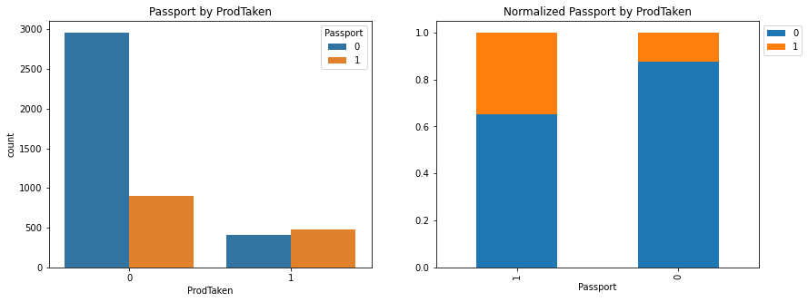

```python
count_and_normalize_plot(data, 'Passport', 'ProdTaken')
```

> **Observations:**
> - Very few about 10% customers who do not have passport, taken a travel package.
> - But normalized chart clearly shows that **close to 40% of customers, who have passport, have taken a travel package**. This observation is very encouraging.